# Project Toni&Suoni

14 Luglio 2023

## Introduzione

In questo progetto verrà sviluppata l’analisi dei dati di vendita di un piccolo negozio di strumenti musicali, situato all’interno di una scuola di musica. Il negozio nasce alla fine del 2018 e, oltre alla vendita di strumenti musicali e di tutti i relativi accessori, vende libri musicali e fornisce servizi di liuteria.

Il progetto si focalizzerà sull’andamento delle vendite dal gennaio 2019 al maggio 2023, considerando:

- Andamento delle vendite per anno
- Stagionalità delle vendite
- Andamento delle vendite per Categoria

## Analisi del Dataset

Per svolgere l’analisi è stato estratto il dataset “Fatturato”(Vendite da gennaio 2019 a maggio 2023) dal programma di gestione del negozio MaestroGold.

Il dataset Fatturato contiene quantità e prezzo degli articoli venduti giornalmente su 8819 righe.

Gli articoli sono stati classificati in 5 categorie di apparteneza.

Su questi dati sono state effettuate le seguenti analisi:

- Descrittiva Univariata (Quantità e Importo)
- Comparazione tra categorie
- Andamento degli importi negli anni

## Analisi Descrittiva Univariata

### Indici di Posizione

Sono state effettuate le analisi descrittive delle variabili: Quantità e Importo sono variabili quantitative è possibile calcolarne gli indici di posizione.

Quantità

```
##    Min. 1st Qu.  Median    Mean 3rd Qu.    Max.
##   1.000   1.000   1.000   1.267   1.000  35.000
```

Importo

```
##    Min. 1st Qu.  Median    Mean 3rd Qu.    Max.
##    0.00   10.00   15.00   31.38   25.00 1050.00
```

## Istogramma Quantità

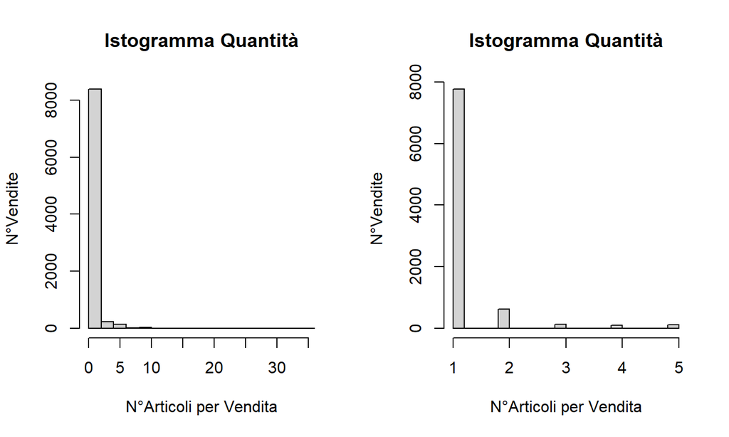

L’istogramma di frequenza mostra che la variabile Quantità non assume la determinazione di una normale.

## Istogramma Importo

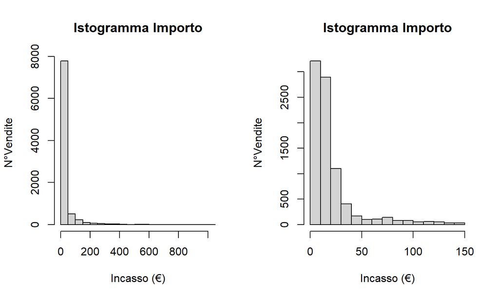

L’istogramma di frequenza mostra che la variabile Importo non assume la determinazione di una normale.

## BoxPlot Importi Annui

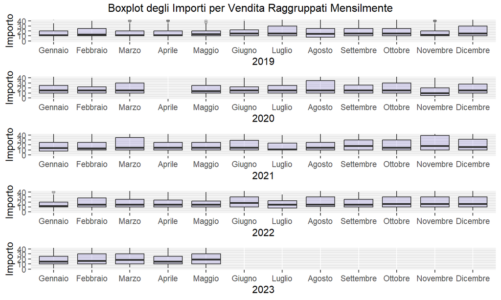

La mancanza di dati di Aprile 2020 è dovuta alla chiusura per il lockdown.

## ColPlot Importi Annui

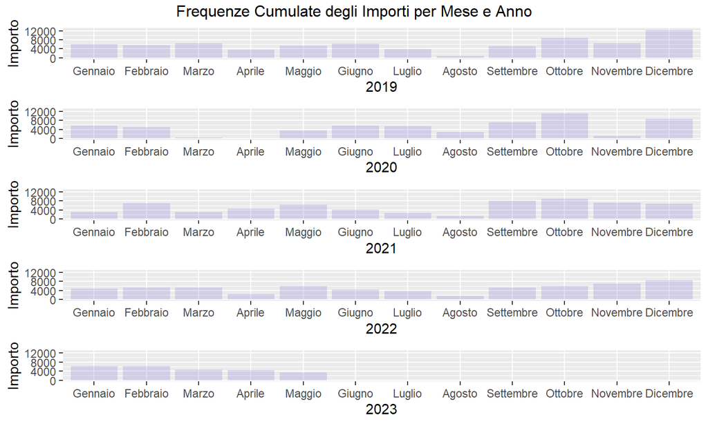

Picchi Settembre, Ottobre e Dicembre : (Scuola e Natale) Depressione Agosto : (Chiusura estiva)

## Areaplot Totale per Importo

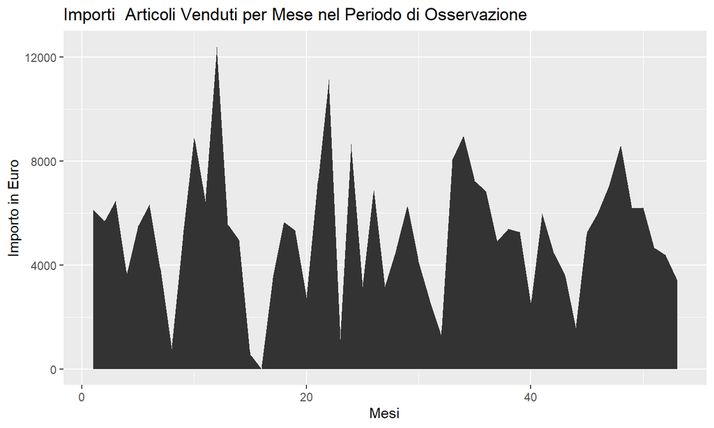

Il grafico evidenzia un andamento non lineare e presenta un pattern stagionale

## Confronto Indici di Posizione Accessori/Strumenti

Accessori

```
##    Min. 1st Qu.  Median    Mean 3rd Qu.    Max.
##     0.0    85.0   121.0   125.4   157.0   290.0
```

```
##    Min. 1st Qu.  Median    Mean 3rd Qu.    Max.
##       0    1169    1748    1624    2005    3240
```

Strumenti

```
##    Min. 1st Qu.  Median    Mean 3rd Qu.    Max.
##    0.00    7.00   13.00   14.58   18.00   53.00
```

```
##    Min. 1st Qu.  Median    Mean 3rd Qu.    Max.
##       0    1100    1776    1983    2669    6565
```

## Confronto Quantità Accessori/Strumenti

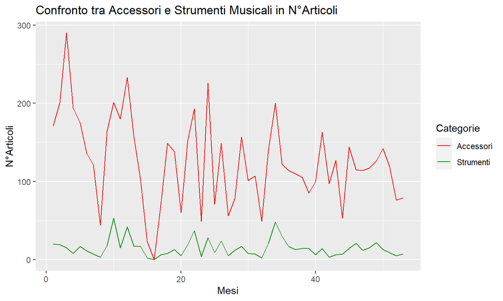

## Confronto Quantità Libri/Strumenti

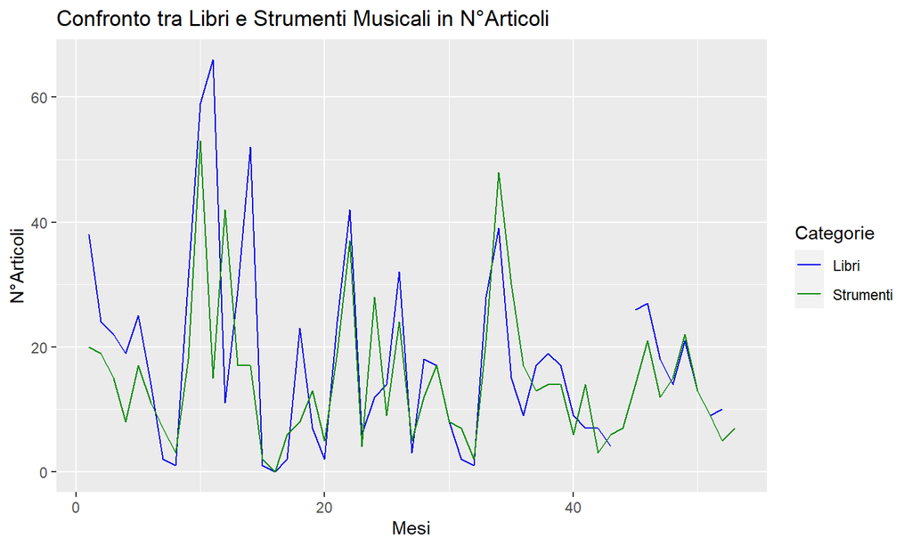

Si nota una correlazione tra le vendite mensili di libri e strumenti.

## Confronto Quantità Liuteria/Strumenti

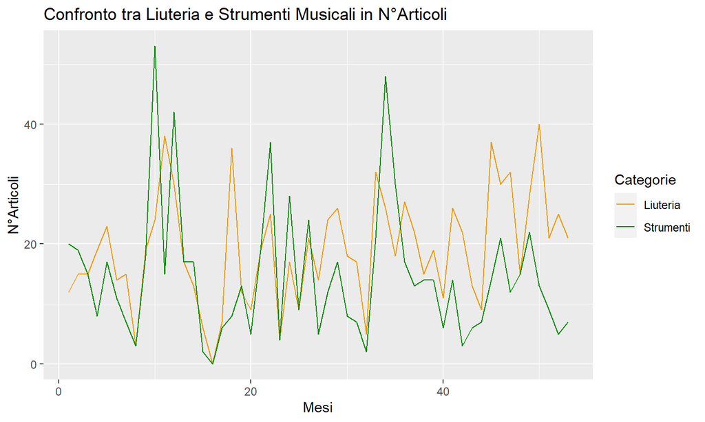

La serie Liuteria ha un pattern stagionale, ma anche un pattern ciclico.

## Confronto Quantità per Categoria

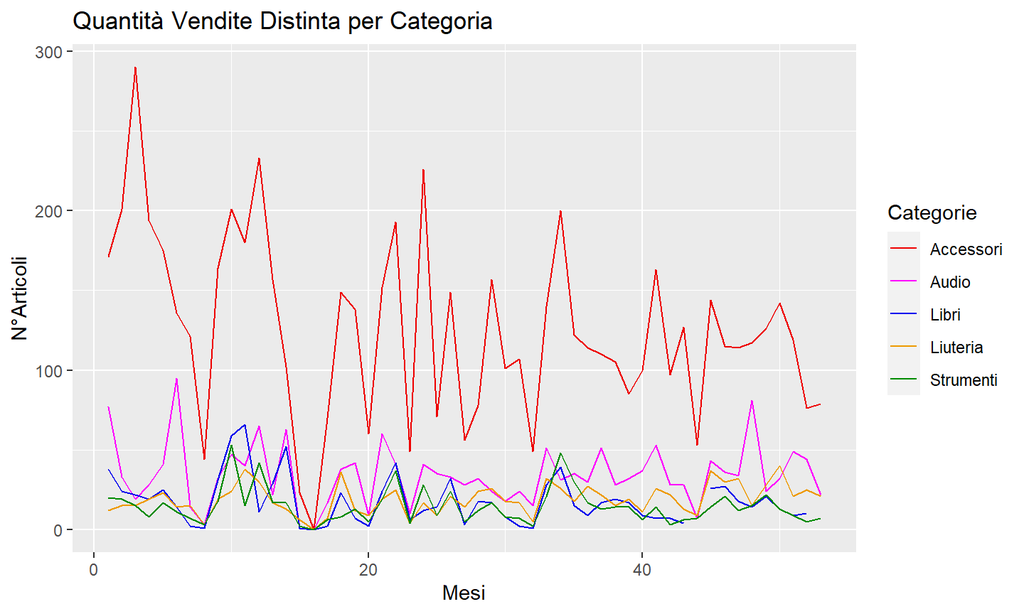

## Confronto Importo per Categoria

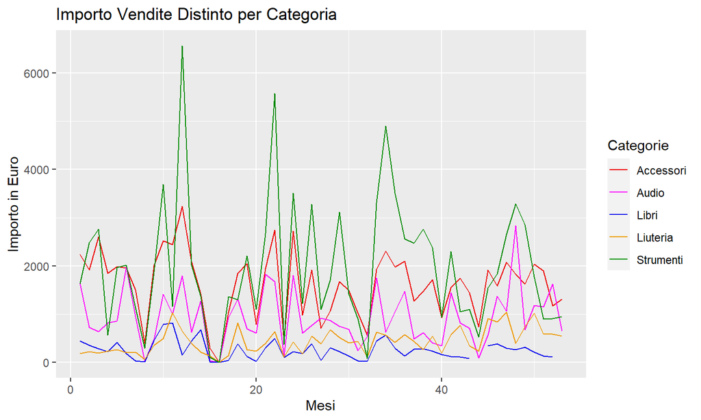

## Andamento Importo Annuo

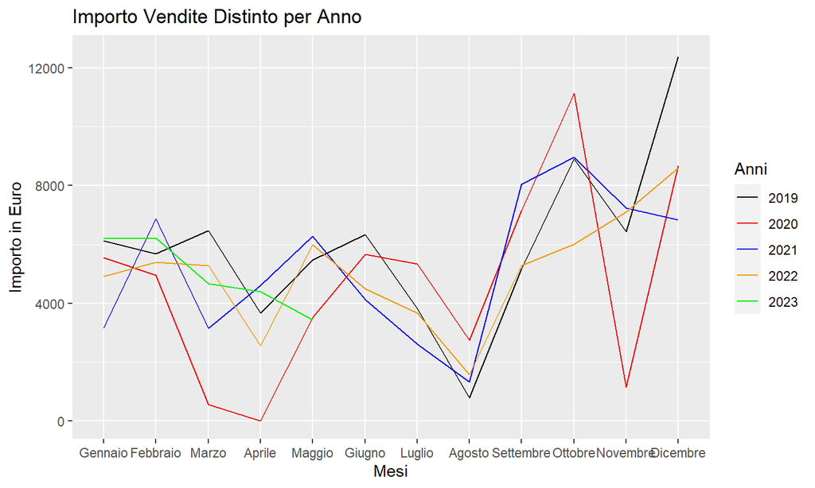

Si rileva la stagionalità negli anni.

## Conclusioni

La serie Liuteria è un esempio di pattern ciclico.

I grafici delle serie storiche delle variabili Quantità e Fatturato:

- Picchi elevati nel mese di Dicembre (festività Natalizie)
- Picchi elevati nei mesi di Settembre e Ottobre (riapertura scuola)
- Picchi minori nei mesi di Maggio e Giugno (Comunioni e Cresime)
- Depressioni nel mese di Agosto (chiusura negozio)

E’ evidente la stagionalità.